# Module 5 Code Lab

Your Name Here

# Introduction

Check the Module Overview for resources that may be helpful with this assignment. See the Code Lab Guidelines page for general directions on Code Lab assignments. See the Dataset Information page for background on the datasets used in the Code Lab assignments.

## Goals

- Add text annotation to a plot
- Add lines and arrows to a plot
- Fill in implicit missing values in a data series
- Label bars on a bar plot
- Color selected bars on a bar plot differently

The examples below start to address style, labels, layout, and other factors that are worth attention once you develop visualizations for broader audiences (move out of the exploratory phase). Some plots below, however, are still exploratory or steps along the path of developing finished visualizations, so not every plot is polished. We’ll continue to add in additional finishing steps over the next few weeks.

# Setup

```r
library(tidyverse)
library(readxl)
library(janitor)
```

## Data files

This assignment uses the WHO data. **Download the WHO data folder from Canvas and put it as a subdirectory of your working directory.** It assumes that the data files are in a subdirectory of the working directory called WHO. Adjust your working directory if needed; do not change the file paths in the code below, or the instructor will not be able to knit your file.

```r
cases <- read_excel("WHO/reported-cases--2020.xlsx") %>% clean_names()
```

Make sure to take a look the data – it’s likely the first time you’re seeing it.

# Yellow Fever

What diseases are in the cases data?

```r
unique(cases$disease)
```

```
##  [1] "PERTUSSIS"          "RUBELLA"            "JAPENC"
##  [4] "DIPHTHERIA"         "CRS"                "MUMPS"
##  [7] "NTETANUS"           "MENING"             "MEASLES"
## [10] "NNTETANUS"          "HIB_MENINGITIS"     "YFEVER"
## [13] "TYPHOID"            "POLIO"              "TTETANUS"
## [16] "INVASIVE_MENING"    "HIB_OTHER"          "HEPATITISB"
## [19] "HEPATITISB_CHRONIC" "VARICELLA"          "HEPATITISA"
## [22] "PNEUMO"
```

## USA & Implicit Missing

Let’s look at cases of [yellow fever](https://www.who.int/news-room/fact-sheets/detail/yellow-fever) (“YFEVER”) over time. Let’s look at the USA (it’s often useful to start with a case you know something about):

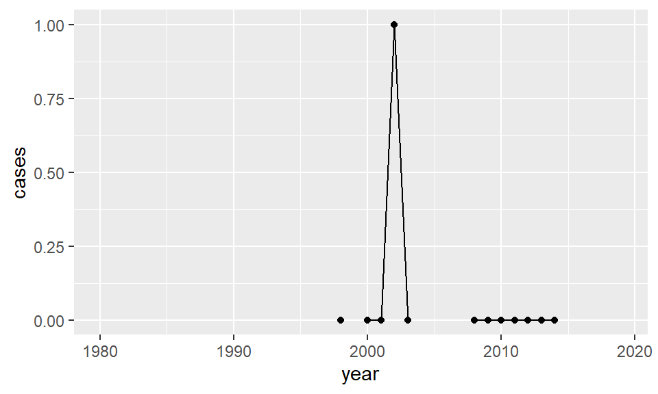

```r
cases %>%
  filter(disease == "YFEVER", group=="Countries", code=="USA") %>%
  ggplot(aes(x=year, y=cases)) +
  geom_line() +
  geom_point()
```

There’s only 1 case ever! But it looks like there must be missing values in the data. Are they implicit (no rows for given years) or explicit (`NA` values).

```r
cases %>%
  filter(disease == "YFEVER", group=="Countries", code=="USA") %>%
  arrange(year)
```

```
## # A tibble: 39 × 7
##    group     code  name                      year disease disease_descri…¹ cases
##    <chr>     <chr> <chr>                    <dbl> <chr>   <chr>            <dbl>
##  1 Countries USA   United States of America  1980 YFEVER  Yellow fever        NA
##  2 Countries USA   United States of America  1981 YFEVER  Yellow fever        NA
##  3 Countries USA   United States of America  1982 YFEVER  Yellow fever        NA
##  4 Countries USA   United States of America  1983 YFEVER  Yellow fever        NA
##  5 Countries USA   United States of America  1984 YFEVER  Yellow fever        NA
##  6 Countries USA   United States of America  1985 YFEVER  Yellow fever        NA
##  7 Countries USA   United States of America  1986 YFEVER  Yellow fever        NA
##  8 Countries USA   United States of America  1987 YFEVER  Yellow fever        NA
##  9 Countries USA   United States of America  1988 YFEVER  Yellow fever        NA
## 10 Countries USA   United States of America  1989 YFEVER  Yellow fever        NA
## # … with 29 more rows, and abbreviated variable name ¹disease_description
```

Should missing data be considered 0? Was there any US reporting for other diseases for the 80s?

```r
cases %>%
  filter(group=="Countries", code=="USA") %>%
  arrange(year)
```

```
## # A tibble: 380 × 7
##    group     code  name                      year disease    disease_des…¹ cases
##    <chr>     <chr> <chr>                    <dbl> <chr>      <chr>         <dbl>
##  1 Countries USA   United States of America  1980 MEASLES    Measles       13506
##  2 Countries USA   United States of America  1980 POLIO      Poliomyelitis     8
##  3 Countries USA   United States of America  1980 NTETANUS   Neonatal tet…     0
##  4 Countries USA   United States of America  1980 PERTUSSIS  Pertussis      1730
##  5 Countries USA   United States of America  1980 TTETANUS   Total tetanus    95
##  6 Countries USA   United States of America  1980 DIPHTHERIA Diphtheria        3
##  7 Countries USA   United States of America  1980 YFEVER     Yellow fever     NA
##  8 Countries USA   United States of America  1981 MEASLES    Measles        3124
##  9 Countries USA   United States of America  1981 DIPHTHERIA Diphtheria        5
## 10 Countries USA   United States of America  1981 YFEVER     Yellow fever     NA
## # … with 370 more rows, and abbreviated variable name ¹disease_description
```

Yes, including some actual 0s. Do global totals equal the sum across countries for each year?

```r
cases %>%
  filter(disease == "YFEVER") %>%
  group_by(group, year) %>%
  summarize(total=sum(cases, na.rm=TRUE)) %>%
  pivot_wider(names_from=group, values_from=total)
```

```
## # A tibble: 41 × 4
##     year Countries Global `WHO Regions`
##    <dbl>     <dbl>  <dbl>         <dbl>
##  1  1980       144    144           144
##  2  1981       238    238           238
##  3  1982       171    171           171
##  4  1983       793    793           793
##  5  1984      1012   1012          1012
##  6  1985       138    138           138
##  7  1986      1477   1477          1477
##  8  1987      3247   3247          3247
##  9  1988      5344   5344          5344
## 10  1989      3507   3507          3507
## # … with 31 more rows
```

These do align. So WHO is treating missing values as 0s - we’ll do the same. How do we fill in the missing values in our plot? By mutating the data before plotting:

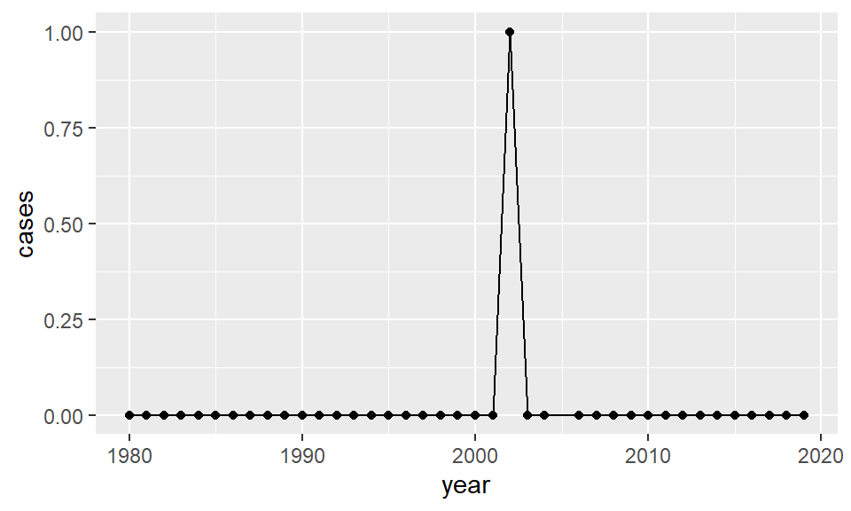

```r
cases %>%
  filter(disease == "YFEVER", group=="Countries", code=="USA") %>%
  # replace NA with 0
  mutate(cases = replace_na(cases, 0)) %>%
  ggplot(aes(x=year, y=cases)) +
  geom_line() +
  geom_point()
```

There’s still an issue though – it looks like there’s no record for 2005 (see the lack of dot at 2005?). The code above only replaced explicit missing values. This may be an implicit missing value, meaning there is no row for the US, YFEVER, 2005.

Double-check to make sure the observation isn’t there (bad data value or some other issue)

```r
cases %>%
  filter(year == 2005, group=="Countries", code=="USA")
```

```
## # A tibble: 8 × 7
##   group     code  name                      year disease    disease_desc…¹ cases
##   <chr>     <chr> <chr>                    <dbl> <chr>      <chr>          <dbl>
## 1 Countries USA   United States of America  2005 CRS        Congenital ru…     1
## 2 Countries USA   United States of America  2005 TTETANUS   Total tetanus     27
## 3 Countries USA   United States of America  2005 POLIO      Poliomyelitis      0
## 4 Countries USA   United States of America  2005 NTETANUS   Neonatal teta…     0
## 5 Countries USA   United States of America  2005 RUBELLA    Rubella           11
## 6 Countries USA   United States of America  2005 PERTUSSIS  Pertussis      25616
## 7 Countries USA   United States of America  2005 DIPHTHERIA Diphtheria         0
## 8 Countries USA   United States of America  2005 MEASLES    Measles           66
## # … with abbreviated variable name ¹disease_description
```

No yellow fever row. Do other countries have 2005 reports?

```r
cases %>%
  filter(year == 2005, group=="Countries", disease=="YFEVER")
```

```
## # A tibble: 194 × 7
##    group     code  name                  year disease disease_description cases
##    <chr>     <chr> <chr>                <dbl> <chr>   <chr>               <dbl>
##  1 Countries AFG   Afghanistan           2005 YFEVER  Yellow fever           NA
##  2 Countries AGO   Angola                2005 YFEVER  Yellow fever            0
##  3 Countries AIA   Anguilla              2005 YFEVER  Yellow fever           NA
##  4 Countries ALB   Albania               2005 YFEVER  Yellow fever            0
##  5 Countries AND   Andorra               2005 YFEVER  Yellow fever            0
##  6 Countries ARE   United Arab Emirates  2005 YFEVER  Yellow fever            0
##  7 Countries ARG   Argentina             2005 YFEVER  Yellow fever            0
##  8 Countries ARM   Armenia               2005 YFEVER  Yellow fever            0
##  9 Countries ASM   American Samoa        2005 YFEVER  Yellow fever           NA
## 10 Countries ATG   Antigua and Barbuda   2005 YFEVER  Yellow fever            0
## # … with 184 more rows
```

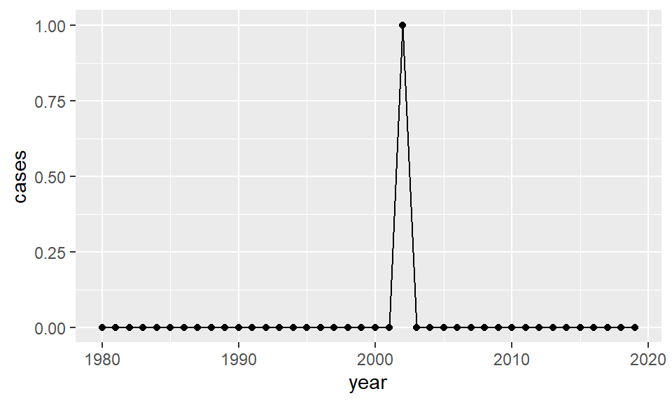

```r
cases %>%
  filter(disease == "YFEVER", group=="Countries", code=="USA") %>%
  # make sure there is a row for every year
  complete(year = full_seq(year, 1),
           # for other variables, make sure all combinations are represented
           group,
           code,
           name,
           disease,
           disease_description) %>%
  # complete will add NAs - make those 0s
  mutate(cases = replace_na(cases, 0))  %>%
  ggplot(aes(x=year, y=cases)) +
  geom_line() +
  geom_point()
```

## Explaining Global Cases

Plot the global trend:

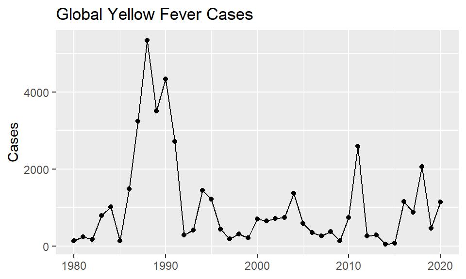

```r
cases %>%
  filter(disease == "YFEVER", group=="Global") %>%
  ggplot(aes(x=year, y=cases)) +
  geom_line() +
  geom_point() +
  labs(title="Global Yellow Fever Cases",
       x=NULL,  ## "year" is obvious - no need for the label here
       y="Cases")
```

# EXERCISE 1

A. Do some research to figure out why yellow fever cases were so high globally in the late 1980s (the plot immediately above). You are welcome to use a combination of investigating the data and internet searches. Were there outbreaks in particular countries?

Share what you learned (briefly):

Research on the internet tells us that in the 1980s the world experienced several yellow fever epidemics in certain tropical areas of Africa and Central and South America.

B. Make one or more plots that would help explain the globally high levels in the late 80s if you needed to explain the peak in a presentation.

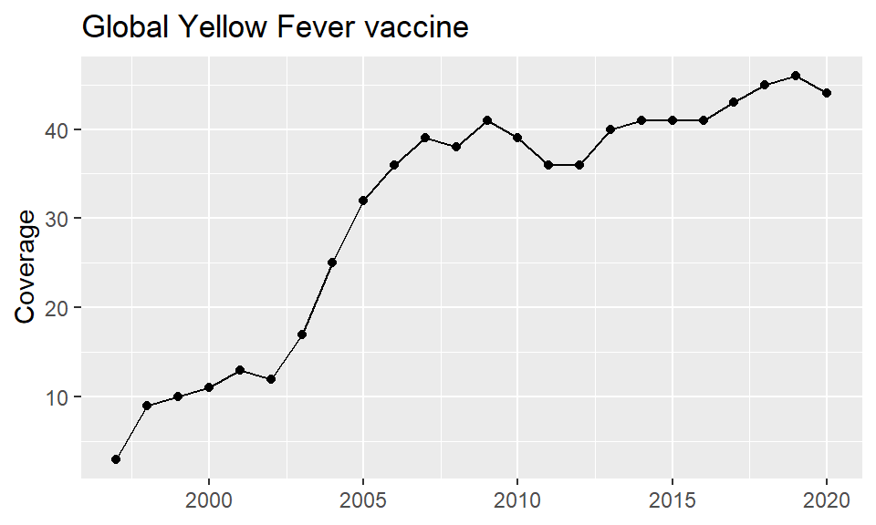

```r
coverage <- read_excel("WHO/coverage--2020.xlsx") %>% clean_names()

coverage %>%
  filter(group=="Global", antigen == "YFV") %>%
  ggplot(aes(x=year, y=coverage)) +
  geom_line() +
  geom_point() +
  labs(title="Global Yellow Fever vaccine",
       x=NULL,  ## "year" is obvious - no need for the label here
       y="Coverage")
```

## Annotating

We may want to label peaks or other key features on a plot.

To add extra information, we use the `annotate()` function. You may also see examples with `geom_text()` or `geom_label()`, but these should only be used when the text you want to put on the plot is already in the data (not text you’re writing).

Starting with this plot:

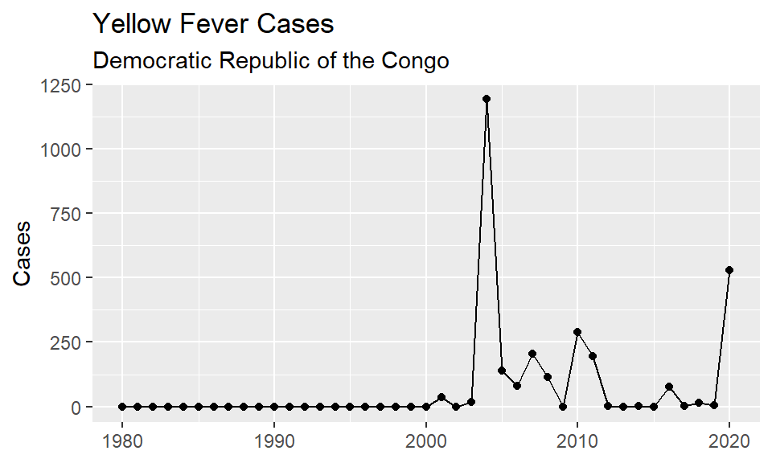

```r
cases %>%
  filter(disease == "YFEVER", group=="Countries", code=="COD") %>%
  complete(year = full_seq(year, 1), group, code, name, disease, disease_description) %>%
  mutate(cases = replace_na(cases, 0))  %>%
  ggplot(aes(x=year, y=cases)) +
  geom_line() +
  geom_point() +
  labs(title="Yellow Fever Cases",
       subtitle="Democratic Republic of the Congo",
       x=NULL, y="Cases")
```

What proportion of global cases is that peak?

```r
filter(cases, disease == "YFEVER", group=="Countries", code=="COD", year == 2004) %>% pull(cases)
```

```
## [1] 1192
```

```r
filter(cases, disease == "YFEVER", group=="Global", year == 2004) %>% pull(cases)
```

```
## [1] 1376
```

```r
1192/1376
```

```
## [1] 0.8662791
```

Add that information to the plot

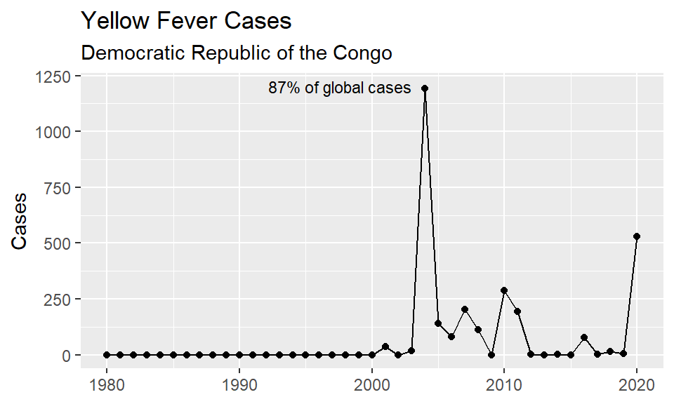

```r
cases %>%
  filter(disease == "YFEVER", group=="Countries", code=="COD") %>%
  complete(year = full_seq(year, 1), group, code, name, disease, disease_description) %>%
  mutate(cases = replace_na(cases, 0))  %>%
  ggplot(aes(x=year, y=cases)) +
  geom_line() +
  geom_point() +
  annotate("text",  # the geom you're using -- what type of thing are you adding?
           x=2003,  # on the same scale as x axis
           y=1200,  # on the same scale as y axis
           label="87% of global cases", # the text to add
           hjust=1,    # how should the text be positioned relative to the given x,y coords?
                       # hjust 1 says to put the right edge at that point
           size=3) +  # this is in mm, not in pts - ratio is 14/5, so 3 = 8.4 pt font
  labs(title="Yellow Fever Cases",
       subtitle="Democratic Republic of the Congo",
       x=NULL, y="Cases")
```

Tip: the only way to really see if a text annotation is in the right place is to produce the plot at the size you want. The dimensions of the figure will affect how much space the text takes up. It may look OK in the preview, but then not in the actual file. So check the knitted file or saved output to make sure.

# EXERCISE 2

Starting from the global plot of yellow fever above (section “Explaining Global Cases”, code chunk “globalyfever”: copy the code as a starting point), add a text annotation for the late 80s peak. Also add a line or arrow (segment) from the text to the region/point. You will need two separate calls to `annotate()` to add both text and a line/arrow).

Note: the `arrow()` function in the grid package is what is needed with ggplot2. `?grid::arrow` will pull up the documentation page.

```r
cases %>%
  filter(disease == "YFEVER", group=="Global")%>%
  mutate(percentage=cases*100/sum(cases, na.rm=TRUE)) %>%
  arrange(desc(cases)) %>%
  slice(1:2)
```

```
## # A tibble: 2 × 8
##   group  code   name    year disease disease_description cases percentage
##   <chr>  <chr>  <chr>  <dbl> <chr>   <chr>               <dbl>      <dbl>
## 1 Global Global Global  1988 YFEVER  Yellow fever         5344       12.4
## 2 Global Global Global  1990 YFEVER  Yellow fever         4339       10.0
```

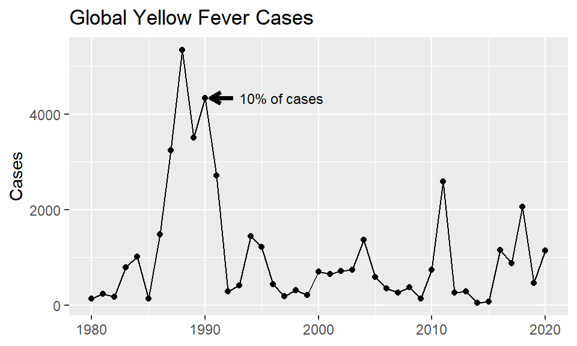

```r
library(grid)

cases %>%
  filter(disease == "YFEVER", group=="Global") %>%
  ggplot(aes(x=year, y=cases)) +
  geom_line() +
  geom_point() +
  labs(title="Global Yellow Fever Cases",
       x=NULL,  ## "year" is obvious - no need for the label here
       y="Cases")+
  annotate("segment", x = 1992.5, xend = 1990.5, y = 4339, yend = 4339,
           size = 1.3, arrow = arrow(length = unit(.25,"cm")))+
  annotate( "text", x=1993, y=4339, label="10% of cases",hjust=0, size=3)
```

## Annotating a Bar Plot

To annotate, you need to supply x and y positions. How do you do this when you have a categorical variable on one of the axes?

How many countries per year report non-zero (and non-missing) yellow fever cases?

If your bar labels happen to be numeric, you can use the numeric values:

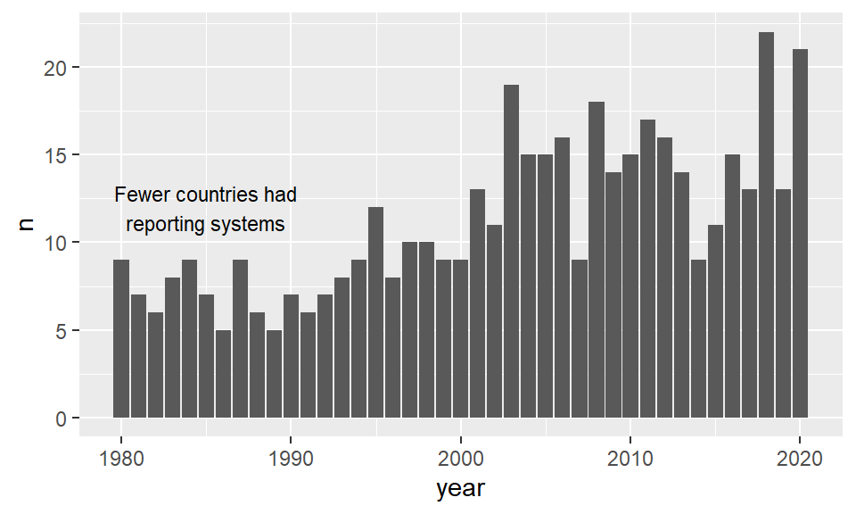

```r
cases %>%
  filter(disease == "YFEVER", group=="Countries", !is.na(cases), cases!=0) %>%
  group_by(year) %>%
  summarize(n=n_distinct(code)) %>%
  ggplot(aes(x=year, y=n)) +
  geom_col() +
  annotate("text", x=1985, y=12, label="Fewer countries had\nreporting systems",
           size=3)
```

For others, you can use the character label.

Which countries had at least one case in the most years?

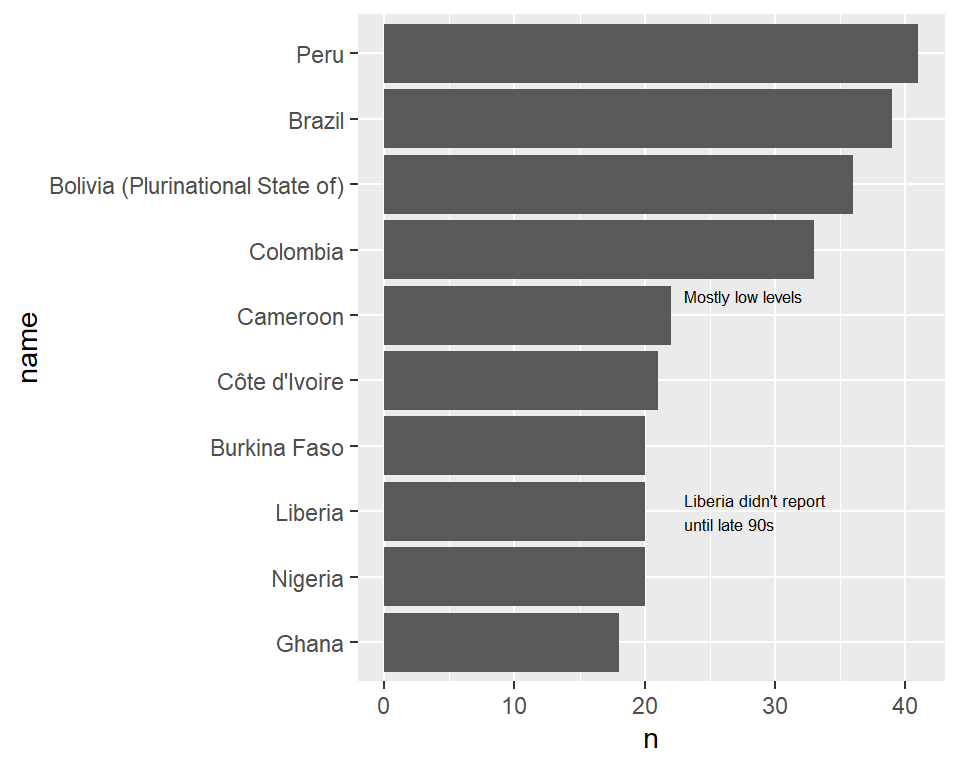

```r
cases %>%
  filter(disease == "YFEVER", group=="Countries", !is.na(cases), cases!=0) %>%
  group_by(name) %>%
  summarize(n=n_distinct(year)) %>%
  slice_max(n, n=10) %>%
  mutate(name = fct_rev(fct_inorder(name))) %>%
  ggplot(aes(x=name, y=n)) +
  geom_col() +
  coord_flip() +
  annotate("text",
           # x and y are switched because of coord_flip
           x="Liberia",   # can use the category name
           y=23,
           hjust=0, label="Liberia didn't report\nuntil late 90s",
           size=2.2) +
  annotate("text",
           x=6.3,   # can use the position instead -- each category takes up 1
           y=23,
           hjust=0, label="Mostly low levels",
           size=2.2)
```

You can use either the category name or the integer position for the axis with a categorical variable. With the position, you don’t have to center it – you can control the position more. See the grid lines behind the bars? There are at integer values. So the label for Cameroon has been placed at 6.3, which is showing slightly above the grid line at 6. The bars are centered on the grid lines.

## Labeling Bars

A common label to add to bar plots is either the bar name (instead of external labels), or the value of the bar.

Starting from this base plot:

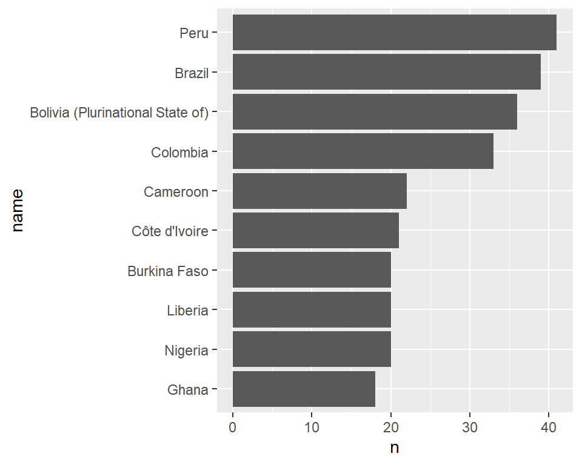

```r
cases %>%
  filter(disease == "YFEVER", group=="Countries", !is.na(cases), cases!=0) %>%
  group_by(name) %>%
  summarize(n=n_distinct(year)) %>%
  slice_max(n, n=10) %>%
  mutate(name = fct_rev(fct_inorder(name))) %>%
  ggplot(aes(x=name, y=n)) +
  geom_col() +
  coord_flip()
```

Sometimes it works to put the labels for each bar on the bar. In such a case, you are pulling the values from the data set (not extra text), so use `geom_text()` instead of `annotate()`.

Also making some other changes to this plot to get it close to a polished version:

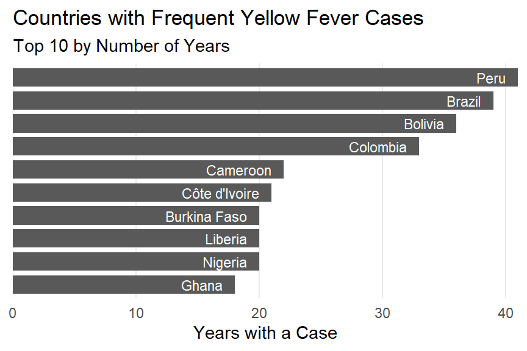

```r
cases %>%
  filter(disease == "YFEVER", group=="Countries", !is.na(cases), cases!=0) %>%
  group_by(name) %>%
  summarize(n=n_distinct(year)) %>%
  slice_max(n, n=10) %>%
  mutate(name = ifelse(str_starts(name, "Bolivia"), "Bolivia", name)) %>%
  mutate(name = fct_rev(fct_inorder(name))) %>%
  ggplot(aes(x=name, y=n)) +
  geom_col(width=.8) +
  geom_text(aes(label=name), hjust=1, nudge_y=-1, color="white", size=3) +
  coord_flip() +
  scale_y_continuous(expand=c(0, NA)) +
  labs(title="Countries with Frequent Yellow Fever Cases",
       subtitle="Top 10 by Number of Years",
       y="Years with a Case",
       x=NULL) +
  theme_minimal() +
  # x and y no longer switched here
  # remove labels
  theme(axis.text.y = element_blank(),
        # remove tick marks
        axis.ticks.y = element_blank(),
        # remove major horizontal grids
        panel.grid.major.y = element_blank(),
        # remove both minor grids
        panel.grid.minor = element_blank())
```

For more on bar labels, see the [R Graphics Cookbook](https://r-graphics.org/recipe-bar-graph-labels)

# EXERCISE 3

Label the bar plot from above (code repeated here):

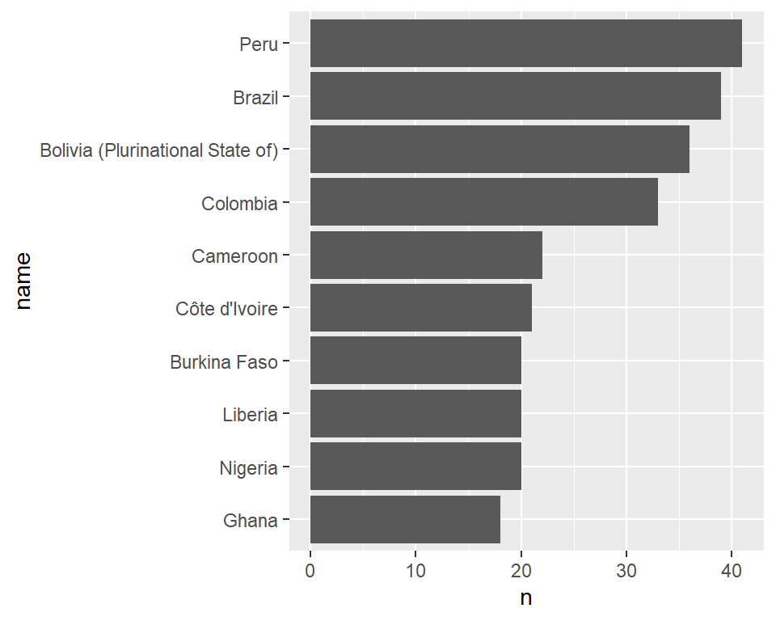

```r
cases %>%
  filter(disease == "YFEVER", group=="Countries", !is.na(cases), cases!=0) %>%
  group_by(name) %>%
  summarize(n=n_distinct(year)) %>%
  slice_max(n, n=10) %>%
  mutate(name = fct_rev(fct_inorder(name))) %>%
  ggplot(aes(x=name, y=n)) +
  geom_col() +
  coord_flip()
```

With the *value* (n) for each country inside each bar

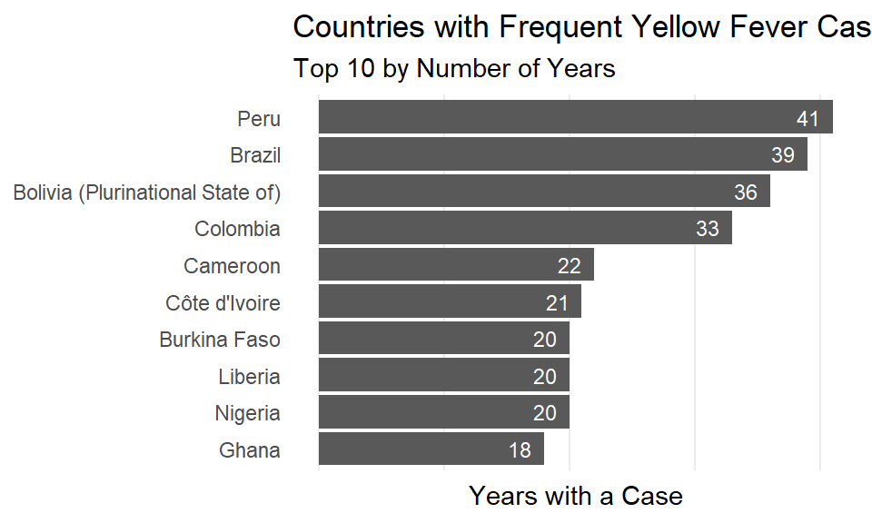

```r
cases %>%
  filter(disease == "YFEVER", group=="Countries", !is.na(cases), cases!=0) %>%
  group_by(name) %>%
  summarize(n=n_distinct(year)) %>%
  slice_max(n, n=10) %>%
  mutate(name = fct_rev(fct_inorder(name))) %>%
  ggplot(aes(x=name, y=n)) +
  geom_col() +
  coord_flip()+
  geom_text(aes(label=n), hjust=1, nudge_y=-1, color="white", size=3)+
  labs(title="Countries with Frequent Yellow Fever Cases",
       subtitle="Top 10 by Number of Years",
       y="Years with a Case",
       x=NULL) +
  theme_minimal() +
  # x and y no longer switched here
  # remove labels
  theme(axis.text.x = element_blank(),
        # remove tick marks
        axis.ticks.x = element_blank(),
        # remove major horizontal grids
        panel.grid.major.y = element_blank(),
        # remove both minor grids
        panel.grid.minor = element_blank())
```

## Coloring Selected Bars

There are two strategies to coloring a subset of the bars. If which bars should be colored can be determined by the data, you can map that variable to the fill color:

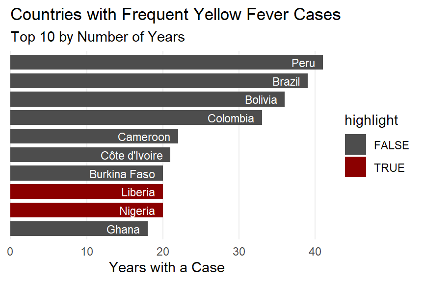

```r
cases %>%
  filter(disease == "YFEVER", group=="Countries", !is.na(cases), cases!=0) %>%
  group_by(name) %>%
  summarize(n=n_distinct(year)) %>%
  slice_max(n, n=10) %>%
  mutate(name = ifelse(str_starts(name, "Bolivia"), "Bolivia", name)) %>%
  mutate(name = fct_rev(fct_inorder(name))) %>%
  # create an indicator variable to use for coloring
  mutate(highlight = name %in% c("Nigeria", "Liberia")) %>%
  # map the new variable to fill color
  ggplot(aes(x=name, y=n, fill=highlight)) +
  geom_col(width=.8) +
  geom_text(aes(label=name), hjust=1, nudge_y=-1, color="white", size=3) +
  coord_flip() +
  scale_y_continuous(expand=c(0, NA)) +
  # set the colors -- more on this in future weeks
  scale_fill_manual(values=c("gray30", "darkred")) +
  labs(title="Countries with Frequent Yellow Fever Cases",
       subtitle="Top 10 by Number of Years",
       y="Years with a Case",
       x=NULL) +
  theme_minimal() +
  # x and y no longer switched here
  # remove labels
  theme(axis.text.y = element_blank(),
        # remove tick marks
        axis.ticks.y = element_blank(),
        # remove major horizontal grids
        panel.grid.major.y = element_blank(),
        # remove both minor grids
        panel.grid.minor = element_blank())
```

As you can see, a legend is added automatically – you can remove this.

Instead, you can also just set the bar colors in the geom function. But to do that, you need a vector of values. You could set this up from the data ahead of time, or do it manually.

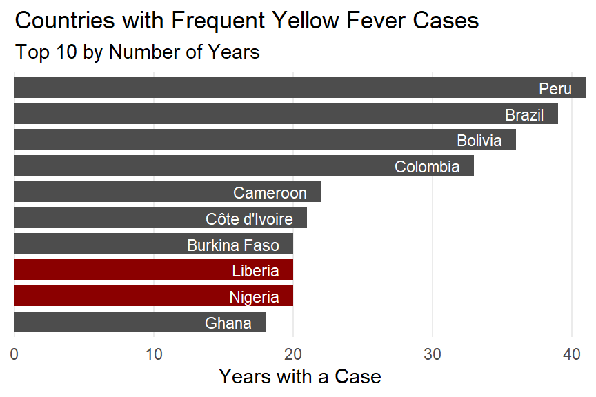

```r
cases %>%
  filter(disease == "YFEVER", group=="Countries", !is.na(cases), cases!=0) %>%
  group_by(name) %>%
  summarize(n=n_distinct(year)) %>%
  slice_max(n, n=10) %>%
  mutate(name = ifelse(str_starts(name, "Bolivia"), "Bolivia", name)) %>%
  mutate(name = fct_rev(fct_inorder(name))) %>%
  ggplot(aes(x=name, y=n)) +
  # just set the color with a vector of values, one for each bar
  geom_col(width=.8,
           # in order of rows in the data, not in the plot (although same here)
           fill=c(rep("gray30",7), "darkred", "darkred", "gray30")) +
  geom_text(aes(label=name), hjust=1, nudge_y=-1, color="white", size=3) +
  coord_flip() +
  scale_y_continuous(expand=c(0, NA)) +
  labs(title="Countries with Frequent Yellow Fever Cases",
       subtitle="Top 10 by Number of Years",
       y="Years with a Case",
       x=NULL) +
  theme_minimal() +
  # x and y no longer switched here
  # remove labels
  theme(axis.text.y = element_blank(),
        # remove tick marks
        axis.ticks.y = element_blank(),
        # remove major horizontal grids
        panel.grid.major.y = element_blank(),
        # remove both minor grids
        panel.grid.minor = element_blank())
```

Note: We’re conflating missing and 0s here – some of the effect above is likely due to countries not reporting in earlier years. We’d need to sort this out in more detail if we were going to present this data. Perhaps leave data as actually missing until the first year data is reported.

## Direct Labels

For plots that would otherwise require a legend, one alternative is to directly label the lines, points, or regions instead of using a legend. This often makes it easier for people to read the plot – they don’t have to look back and forth between the plot and legend, trying to match up colors or patterns. The labels are available for them instead.

As a rule of thumb:

- If you have just a few labels to add, and you want to position them precisely, use `annotate()`
- If you’re labeling multiple things in the same way, try `geom_text()`

There are also packages, most notably directlabels and ggrepel, that you can use. These are helpful when the labels may otherwise overlap with each other.

Let’s work with a line plot of yellow fever cases for a few select countries.

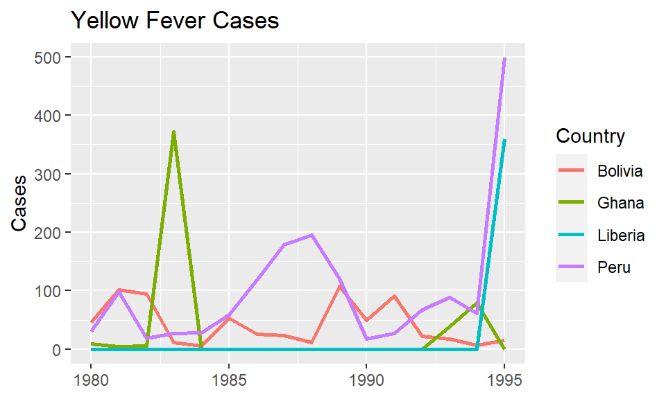

```r
cases %>%
  filter(disease == "YFEVER", code %in% c("PER", "LBR", "BOL", "GHA"), year <= 1995) %>%
  mutate(name = ifelse(str_starts(name, "Bolivia"), "Bolivia", name)) %>%
  # note the use of "nesting" below -- otherwise you get combinations of these variables
  complete(year = full_seq(year, 1), nesting(group, code, name), disease, disease_description) %>%
  mutate(cases = replace_na(cases, 0))  %>%
  ggplot(aes(x=year, y=cases, color=name)) +
  geom_line(size=1) +
  labs(title="Yellow Fever Cases",
       x=NULL, y="Cases",
       color="Country")
```

While ordering the legend entries in the order of the lines would help, direct labels could help more:

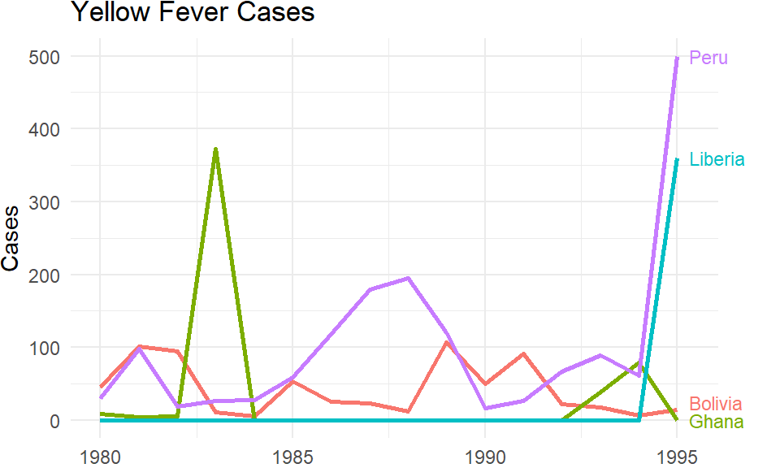

```r
cases %>%
  filter(disease == "YFEVER",
         code %in% c("PER", "LBR", "BOL", "GHA"), year <= 1995) %>%
  mutate(name = ifelse(str_starts(name, "Bolivia"), "Bolivia", name)) %>%
  # note the use of "nesting" below --
  # otherwise you get combinations of these variables
  complete(year = full_seq(year, 1),
           nesting(group, code, name), disease, disease_description) %>%
  mutate(cases = replace_na(cases, 0))  %>%
  ggplot(aes(x=year, y=cases, color=name)) +
  geom_line(size=1) +
  # add direct labels
  geom_text(aes(label=name),
            # just label the final points
            data = . %>% filter(year == 1995),
            hjust=0,
            # shift labels to the right a little
            nudge_x = .3,
            size=3,
            # address overlap in labels
            nudge_y=c(10, 0, 0, 0)) +
  # let labels go off the right side of the plot
  coord_cartesian(clip="off") +
  labs(title="Yellow Fever Cases",
       x=NULL, y="Cases",
       color="Country") +
  theme_minimal() +
  # remove legend
  theme(legend.position = "none",
        # make space at the right side of the plot for the labels
        plot.margin = margin(r=1, unit="cm"))
```

# EXERCISE 4: Measles

This code might help you figure out what’s going on:

```r
cases %>%
  filter(group=="Countries", disease=="MEASLES", year >= 2000) %>%
  group_by(name) %>%
  summarize(total = sum(cases, na.rm=TRUE),
            average = mean(cases, na.rm=TRUE),
            v2019 = cases[year==2019],
            change = cases[year==2019]-cases[year==2016]) %>% View()

cases %>%
  filter(group=="Countries", disease=="MEASLES", year == 2019) %>%
  mutate(prop = cases/sum(cases, na.rm=TRUE)) %>%
  slice_max(prop, n=10)
```

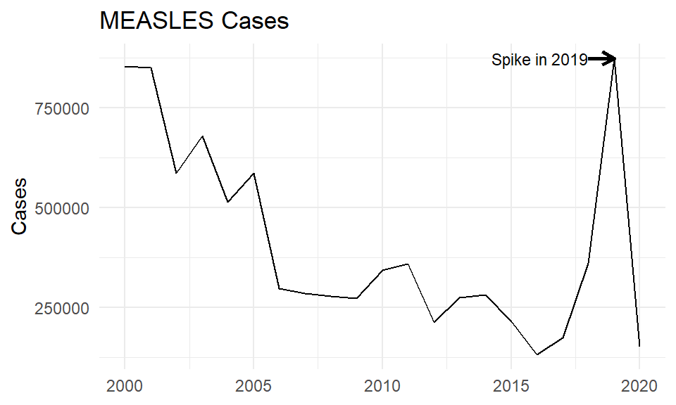

```r
cases %>%
  filter(group=="Countries", disease=="MEASLES", year >= 2000) %>%
  group_by(year) %>%
  summarize(total = sum(cases, na.rm=TRUE),
            average = mean(cases, na.rm=TRUE)) %>%
  ggplot()+
  geom_line(aes(x = year, y=total))+
  labs(title="MEASLES Cases",
       x=NULL, y="Cases") +
  annotate("segment", x = 2018, xend = 2019, y = 873378, yend = 873378,
           size = 1, arrow = arrow(length = unit(.25,"cm")))+
  annotate( "text", x=2018, y=873378, label="Spike in 2019",hjust=1, size=3)+
  theme_minimal()
```

The peak in 2019 of the number of MEASLES cases can be visualized quite well.

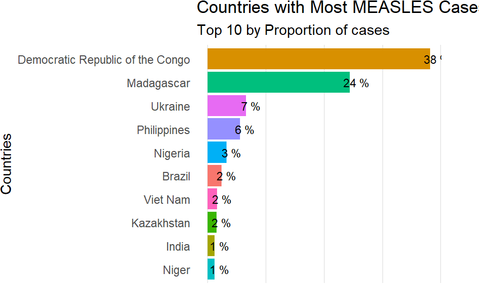

```r
cases %>%
  filter(group=="Countries", disease=="MEASLES", year == 2019) %>%
  mutate(prop = cases/sum(cases, na.rm=TRUE)) %>%
  slice_max(prop, n=10) %>%
  ggplot(aes(x=prop, y=reorder(name,prop), fill=name))+
  geom_col()+
  geom_text(aes(label=paste(round(prop*100),"%")), hjust=0.25, size=3) +
  labs(title="Countries with Most MEASLES Cases in 2019",
       subtitle="Top 10 by Proportion of cases",
       y="Countries",
       x=NULL) +
  theme_minimal() +
  # remove legend
  theme(legend.position = "none",
        # make space at the right side of the plot for the labels
        plot.margin = margin(r=1, unit="cm"),
        axis.text.x = element_blank(),
        # remove tick marks
        axis.ticks.x = element_blank(),
        # remove major horizontal grids
        panel.grid.major.y = element_blank(),
        # remove both minor grids
        panel.grid.minor = element_blank())
```

In 2019, we observe a large number of cases of MEASLES in the countries: Democratic Republic of the Congo”, “Madagascar

```r
cases %>%
  filter(group=="Countries", disease=="MEASLES", year >= 2000) %>%
  group_by(name) %>%
  summarize(total = sum(cases, na.rm=TRUE),
            average = mean(cases, na.rm=TRUE),
            v2019 = cases[year==2019],
            change = cases[year==2019]-cases[year==2016]) %>%
  filter(name %in% c("Democratic Republic of the Congo", "Madagascar", "Ukraine", "Philippines"))
```

```
## # A tibble: 4 × 5
## # Groups:   name [4]
##   name                               total average  v2019 change
##   <chr>                              <dbl>   <dbl>  <dbl>  <dbl>
## 1 Democratic Republic of the Congo 1237839  61892. 333017 327925
## 2 Madagascar                        388663  19433. 213231 213226
## 3 Philippines                       190643   9078.  48525  47809
## 4 Ukraine                           201972  11221.  57282  57180
```

Given the wide variation in the number of cases in 2016 and 2019 in the two countries (Democratic Republic of the Congo and Madagascar), it can be assumed that both countries experienced an epidemic in 2019.

# Note

While there is a lot you can do with annotations and various types of labels in R, sometimes it can just be easier to add labels in Adobe Illustrator or another graphics program. In such cases, produce and export a PDF file with the core visualization components, then edit further. You want to avoid this as much as possible, however, since if you make any change to the plot, you have to re-do the manual annotations.